# Integral doble para una función de densidad de probabilidad (fdp) conjunta

Esteban Arroyo

30-03-2026

el ejemplo 5.6 de la guía de vectores aleatorios se tiene la siguiente fdp conjunta: $𝑓(𝑥, 𝑦) = 6𝑥𝑦^2, 0 < 𝑥 < 1, 0 < 𝑦 < 1.$

Se pide verificar que sea una fdp conjunta.

1. En 1er lugar se puede verificar que se cumple que $𝑓(𝑥, 𝑦)\ge0$ para todo (x,y)
2. En segundo lugar, hay que demostrar que la integral sobre todo su soporte es igual a 1.

Para este segundo punto hay que plantear una integral doble, con sus recpectivos soportes, por tanto la condición es:

$$\int_{0}^{1} \int_{0}^{1} 6xy^2 \, dy \,
dx = 1$$
Para resolverlo, primero se integra respecto a $y$ y luego respecto a $x$.

**Paso 1: Resolver la integral interna (respecto a $y$)**

En este paso, tratamos a $x$ como si fuera una constante.

$$\int_{0}^{1} 6xy^2 \, dy = 6x
\int_{0}^{1} y^2 \, dy$$
Aplicamos la regla de la potencia para integrales ($\int y^n dy = \frac{y^{n+1}}{n+1}$):

$$6x \left[ \frac{y^3}{3} \right]_{0}^{1}
= 6x \left( \frac{1^3}{3} - \frac{0^3}{3} \right) = 6x \left(
\frac{1}{3} \right) = 2x$$

**Paso 2: Resolver la integral externa (respecto a $x$)**

Ahora se toma el resultado del paso anterior ($2x$) y lo integramos respecto a $x$ en sus límites correspondientes:

$$\int_{0}^{1} 2x \, dx$$
Volvemos a aplicar la regla de la potencia:

$$\left[ \frac{2x^2}{2} \right]_{0}^{1} =
[x^2]_{0}^{1}$$
Evaluamos en los límites:

$$(1)^2 - (0)^2 = 1 - 0 = 1$$

Verificamos que la integral doble de la función sobre el soporte definido es exactamente 1 y la función $6xy^2$ es mayor o igual a cero en el intervalo $[0,1]$, por lo tanto, se confirma matemáticamente que es una fdp conjunta válida según **Casella y Berger.**

Esto mismo se puede hacer en R con el siguiente código:

```r
##install.packages("cubature")  #si no tienen esta librería hay que instalarla
library(cubature)
f <- function(x, y) 6*x*y^2
resultado <- adaptIntegrate(function(arg) f(arg[1], arg[2]), lowerLimit = c(0, 0), upperLimit = c(1, 1))
resultado$integral
```

```
[1] 1
```

Para graficarla podemos usar este código:

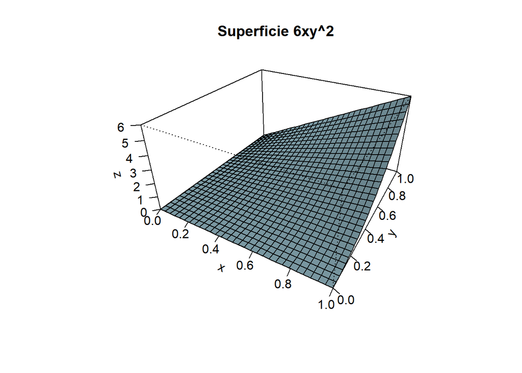

```r
# Definir la función
f <- function(x, y) { 6 * x * y^2 }

# Crear la malla de puntos (grid)
x <- seq(0, 1, length.out = 30)
y <- seq(0, 1, length.out = 30)
z <- outer(x, y, f) # Calcula z = f(x, y) para toda la malla


persp(x, y, z,
      theta = 30, phi = 30, # Ángulos de visualización
      expand = 0.5, col = "lightblue",
      shade = 0.5, ticktype = "detailed",
      main = "Superficie 6xy^2")
```

En este caso, no se va a integrar sobre todo el cuadrado unitario, sino solo sobre una “parte” de él.

Se pide calcular la probabilidad de que la suma sea mayor a 1:

$$X + Y > 1$$

Al despejar $X$, por ejemplo, la la condición nos dice que:

$$X > 1 - Y$$

Aunque $X$ y $Y$ pueden ir de 0 a 1 de forma independiente, la condición $X + Y > 1$ define una línea diagonal que corta el cuadrado, generando un triángulo.Entonces, los puntos que cumplen la condición están por encima de la línea $x = 1 - y$.

Entonces al plantear la doble integral, la integral externa ($dy$) sigue yendo desde 0 hasta 1.Y para la integral interna ($dx$), el soporte va de $1 - Y$ hasta 1.

$$P(X+Y > 1) = \int_{0}^{1}
\int_{1-y}^{1} 6xy^2 \, dx \, dy$$

Podemos verlo gráficamente de esta forma:

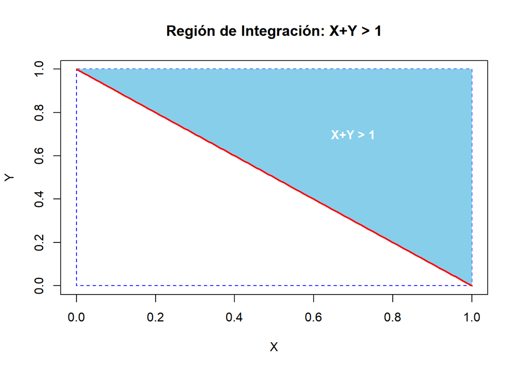

```r
# 1. Definir los límites del gráfico
plot(NULL, xlim=c(0, 1), ylim=c(0, 1),
     xlab="X", ylab="Y", main="Región de Integración: X+Y > 1")

# 2. Dibujar el cuadrado unitario de referencia
rect(0, 0, 1, 1, border="blue", lty=2)

# 3. Definir la línea frontera x + y = 1 => y = 1 - x
x_vals <- seq(0, 1, length.out=100)
y_line <- 1 - x_vals

# 4. Sombrear la región superior derecha (X+Y > 1)
polygon(c(x_vals, 1, 0), c(y_line, 1, 1), col="skyblue", border=NA)

# 5. Dibujar la línea frontera de nuevo para que quede encima
lines(x_vals, y_line, col="red", lwd=2)

# Añadir etiquetas
text(0.7, 0.7, "X+Y > 1", col="white", font=2)
```

**Resolviendo el cálculo de la doble integral**

Resolver la integral para $P(X + Y > 1)$ con la función $f(x, y) = 6xy^2$ en el soporte unitario.

**Paso 1: Integral interna (respecto a $x$)**

Considerar a $y$ como una constante:

$$\int_{1-y}^{1} 6xy^2 \, dx = 6y^2
\int_{1-y}^{1} x \, dx$$
Aplicamos la regla de la potencia ($\frac{x^2}{2}$):

$$6y^2 \left[ \frac{x^2}{2}
\right]_{1-y}^{1} = 3y^2 \left[ x^2 \right]_{1-y}^{1}$$

Evaluamos los límites superior e inferior en $x$:

$$3y^2 \left( (1)^2 - (1-y)^2
\right)$$
$$3y^2 \left( 1 - (1 - 2y +
y^2) \right)$$
$$3y^2 \left( 1 - 1 +
2y - y^2 \right) = 3y^2 (2y - y^2)$$

Multiplicamos para simplificar antes de la siguiente integral:

$$6y^3 - 3y^4$$

**Paso 2: Integral externa (respecto a $y$)**

Tomamos el resultado anterior e integramos respecto a $y$ de $0$ a $1$:

$$\int_{0}^{1} (6y^3 - 3y^4) \,
dy$$

Integramos cada término:

$$\left[ \frac{6y^4}{4} - \frac{3y^5}{5}
\right]_{0}^{1}$$

$$\left[ \frac{3y^4}{2} - \frac{3y^5}{5}
\right]_{0}^{1}$$

Evaluamos en los límites:

$$\left( \frac{3(1)^4}{2} -
\frac{3(1)^5}{5} \right) - (0 - 0)$$

$$\frac{3}{2} - \frac{3}{5} =
\frac{15}{10} - \frac{6}{10} = \frac{9}{10}$$

**Finalmente:**

$$P(X + Y > 1) = \frac{9}{10} =
0.9$$

También lo podemos hacer más rápido en R:

```r
# Calcular (𝑋 + 𝑌 ≥ 1) del ejemplo 5.6 (Vectores Aleatorios)
f <- function(x, y) 6 * x * y^2

# 1. Integral interna (respecto a x) con límite inferior dependiente de y
interna <- function(y) {
  sapply(y, function(val_y) {
    integrate(function(x) f(x, val_y), lower = 1 - val_y, upper = 1)$value
  })
}

# 2. Integral externa (respecto a y) de 0 a 1
resultado_final <- integrate(interna, lower = 0, upper = 1)
resultado_final$value
```

```
[1] 0.9
```